# Summary

Johnson ODEJIDE

2023-03-05

## Plot the estimated regression function

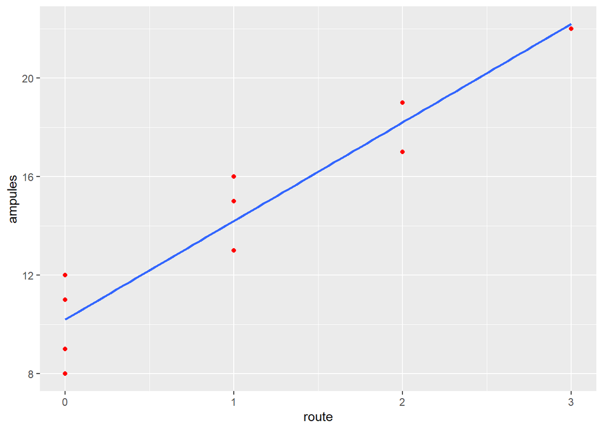

```r
route <- c(1, 0, 2, 0, 3, 1, 0, 1, 2, 0)
ampules <- c(16, 9, 17, 12, 22, 13, 8, 15, 19, 11)

df = tibble(route, ampules)

df %>%
  ggplot(aes(x = route, y = ampules)) +
  geom_point(color = "red") +
  geom_smooth(method = "lm", se = F, formula = y ~ x)
```

## Fit a regression line

```r
lm.fit <- lm(ampules ~ route)
summary(lm.fit)
```

```
##
## Call:
## lm(formula = ampules ~ route)
##
## Residuals:
##    Min     1Q Median     3Q    Max
##   -2.2   -1.2    0.3    0.8    1.8
##
## Coefficients:
##             Estimate Std. Error t value Pr(>|t|)
## (Intercept)  10.2000     0.6633  15.377 3.18e-07 ***
## route         4.0000     0.4690   8.528 2.75e-05 ***
## ---
## Signif. codes:  0 '***' 0.001 '**' 0.01 '*' 0.05 '.' 0.1 ' ' 1
##
## Residual standard error: 1.483 on 8 degrees of freedom
## Multiple R-squared:  0.9009, Adjusted R-squared:  0.8885
## F-statistic: 72.73 on 1 and 8 DF,  p-value: 2.749e-05
```

## Estimate a slope

Estimate the increase in the expected number of ampules broken when there are 2 transfers as compared to 1 transfer. (Hint: Use the slope of the model)

```r
# The formula is given as
# y(hat) = 10.2 + 4x

# when x = 1
yhat_1 <- 10.2 + 4*1

yhat_1
```

```
## [1] 14.2
```

```r
# Calculate for when X = 2
yhat_2 <- 10.2 + 4*2

# Estimate the increase
slope <- yhat_2 - yhat_1
slope
```

```
## [1] 4
```

## Find specific residual for Xi = 3. Show all of your work . Determine if the observed value of 22 is above or below average.

```r
# For x = 3
# y_hat = 10.2 + 4*3
# y_hat = 10.2 + 12 = 22.2
# residual for X3 = 22.2 - 22 = 0.2 (Below average because it is negative)

yhat <- 10.2 + 4 * 3
residual <- 22 - yhat # Where 22 is the observed value
residual
```

```
## [1] -0.2
```

**Conclusion:** Since the residual is negative, we conclude that it is below average

## Verify that your fitted regression line goes through the point (Xbar,Ybar)

```r
Xbar = mean(route)
Ybar = mean(ampules)
# To verify that the fitted regression line goes through the point, we substitute x in the equation for Xbar, that is, 1 and verify if it is 14.2

yhat <- 10.2 + 4 * 1
print(paste("yhat = ", yhat))
```

```
## [1] "yhat =  14.2"
```

```r
print(paste("Xbar = ", Xbar, ", Ybar = ", Ybar, "Yhat at points(1, 14.2) = ", yhat))
```

```
## [1] "Xbar =  1 , Ybar =  14.2 Yhat at points(1, 14.2) =  14.2"
```

**Remark:**

The fitted regression line goes through the point at xbar = 1 and ybar = 14.2 since yhat and ybar are the same value.

## Interpretation of the Multiple R-Squared

Which value in the R summary output table determines if your model is doing a good job explaining the variation in the dependent variable produced by the model. In this case identify this specific proportion of variation.

The Multiple R-squared does the job of explaining the variation in the dependent variable produced by the model.

In this case, the Multiple R-Squared is 0.9009 meaning that about 90% of the variability in the dependent variable (ampules) can be explained by the model.

## Computation of confidence interval in R

```r
X = c(1, 0, 2, 0, 3, 1, 0, 1, 2, 0)
Y = c(16, 9, 17, 12, 22, 13, 8, 15, 19, 11)

d.data <- tibble(X, Y)

conf.95 <- qt(p=.025, df=8, lower.tail = FALSE)

# conf.95

lm.fit <- lm(Y ~ X, data = d.data)
lm.fit
```

```
##
## Call:
## lm(formula = Y ~ X, data = d.data)
##
## Coefficients:
## (Intercept)            X
##        10.2          4.0
```

```r
# summary(lm.fit)

# qt(p=.025, df=8, lower.tail = FALSE)
# 4.00 +/- 2.306(0.469)

# upper bound = Estimate of X + conf.95 * Std. Error of X
# lower bound = Estimate of X - conf.95 * Std. Error of X
upper_bound <- 4.00 + 2.306 * 0.469
lower_bound <- 4.00 - 2.306 * 0.469

conf.int <- c(lower_bound, upper_bound)
conf.int
```

```
## [1] 2.918486 5.081514
```

## Raw computation of confidence interval

se = 0.4690

df = 8

b +/- t(se)

t = 2.306004

4.0 +/- 2.306004(0.4690)

confidence interval = (4.0 - 2.306004(0.4690), 4.0 + 2.306004(0.4690))

= (2.9185, 5.0815)

## Difference between confidence interval and prediction interval

While the prediction interval predicts in what range a future observation will fall, the confidence interval shows in what range of values the prediction falls based on some data provided already. In summary, confidence interval predicts what is available within the limits of the data while prediction interval is able to predict the future.

## Prediction Interval in R

```r
new_df <- data.frame(X = 19)

predict(object = lm.fit, newdata = new_df, interval = "prediction") %>%
cbind(new_df)
```

|  | fit | lwr | upr | X |
| --- | --- | --- | --- | --- |
| 1 | 86.2 | 66.40325 | 105.9967 | 19 |

## Confidence Interval in Prediction

```r
predict(object = lm.fit, newdata = new_df, interval = "confidence") %>%
cbind(new_df)
```

|  | fit | lwr | upr | X |
| --- | --- | --- | --- | --- |
| 1 | 86.2 | 66.70097 | 105.699 | 19 |

**Remarks on Prediction and Confidence Interval**

Prediction Interval when X = 19 (66.4033, 105.9967)

Confidence Interval when X = 19 (66.701, 105.699)

## Plotting Residuals using QQplot

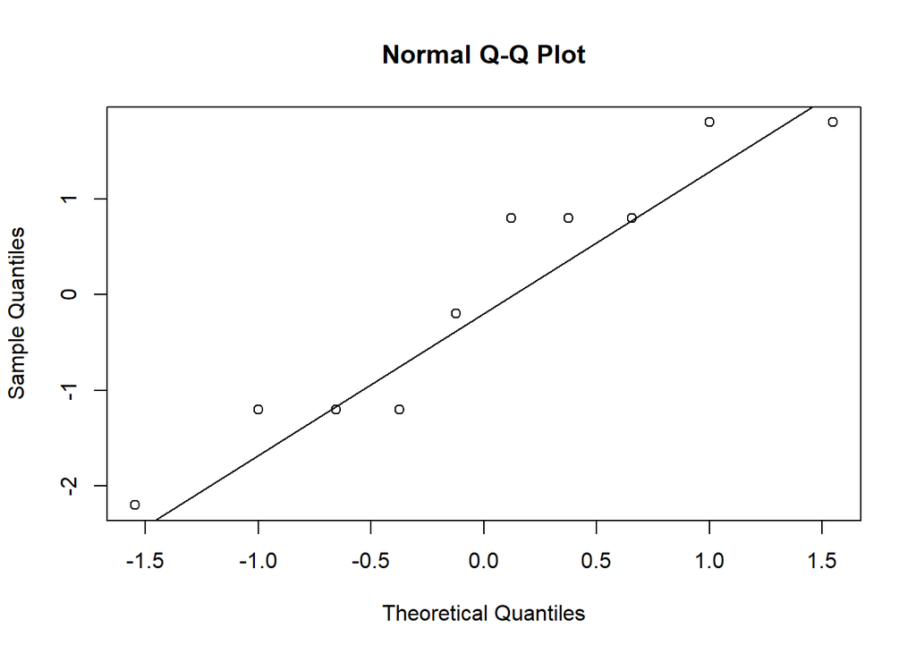

```r
qqnorm(lm.fit$residuals)
qqline(lm.fit$residuals)
```

## Confidence Interval (Method 2) - 95%

```r
confint(lm.fit, '(Intercept)', level = 0.95)
```

```
##               2.5 %   97.5 %
## (Intercept) 8.67037 11.72963
```

```r
## Confidence Interval

confint(lm.fit, level = 0.95)
```

```
##                2.5 %    97.5 %
## (Intercept) 8.670370 11.729630
## X           2.918388  5.081612
```

## Get second residual value

```r
lm.fit.res <- residuals(lm.fit)
lm.fit.res[2]
```

```
##    2
## -1.2
```

## Residual plot (Box plot)

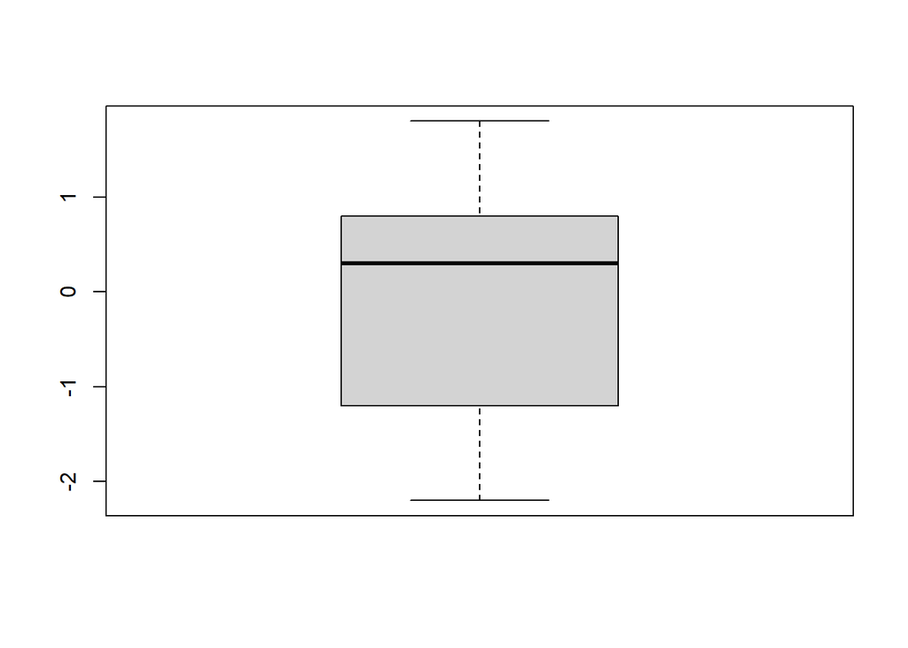

```r
boxplot(residuals(lm.fit))
```

## Residual plots (Scatter plot)

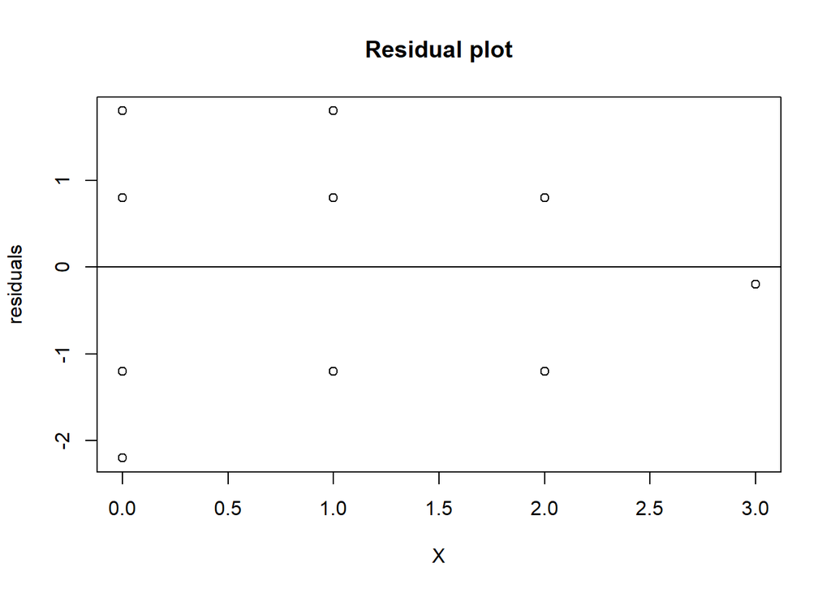

```r
lm.resid <- resid(lm.fit)

plot(d.data$X , lm.resid,
     xlab = "X",
     ylab = "residuals",
     main = "Residual plot")
abline(0, 0)
```

## Residual against Fitted Plot

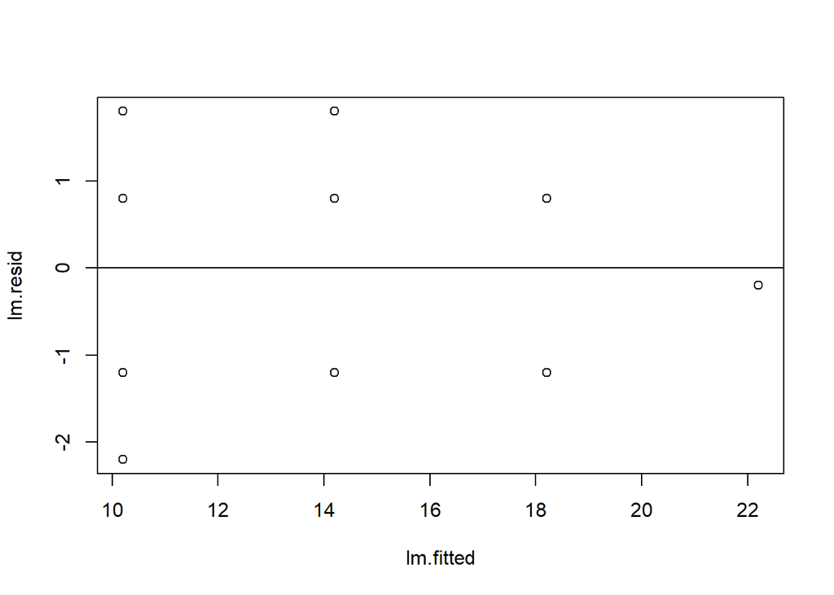

```r
lm.fitted <- fitted(lm.fit)

plot(lm.fitted, lm.resid)
abline(0, 0)
```

## To reject null hypotheses or not?

```r
x <- c(9,9,9,7,7,7,5,5,5,3,3,3,1,1,1)
y<- c(.07,.09,.08,.16,.17,.21,.49,.58,.53,1.22,1.15,1.07,2.84,2.57,3.10)

linear <- lm(y ~ x)
summary(linear)
```

```
##
## Call:
## lm(formula = y ~ x)
##
## Residuals:
##     Min      1Q  Median      3Q     Max
## -0.5333 -0.4043 -0.1373  0.4157  0.8487
##
## Coefficients:
##             Estimate Std. Error t value Pr(>|t|)
## (Intercept)   2.5753     0.2487  10.354 1.20e-07 ***
## x            -0.3240     0.0433  -7.483 4.61e-06 ***
## ---
## Signif. codes:  0 '***' 0.001 '**' 0.01 '*' 0.05 '.' 0.1 ' ' 1
##
## Residual standard error: 0.4743 on 13 degrees of freedom
## Multiple R-squared:  0.8116, Adjusted R-squared:  0.7971
## F-statistic: 55.99 on 1 and 13 DF,  p-value: 4.611e-06
```

```r
anova(linear)
```

|  | Df | Sum Sq | Mean Sq | F value | Pr(>F) |
| --- | --- | --- | --- | --- | --- |
| x | 1 | 12.597120 | 12.5971200 | 55.99384 | 4.611199e-06 |
| Residuals | 13 | 2.924653 | 0.2249733 | NA | NA |

```r
f.value <- 55.994

f.critical <- qf(p = 0.025, df1 = 1, df2 = 13, lower.tail = FALSE)

print(paste("F value = ", f.value, "F Critical = ", f.critical))
```

```
## [1] "F value =  55.994 F Critical =  6.41425430025058"
```

```r
ifelse(f.value > f.critical, "Reject the null hypothesis", "Fail to reject the null hypothesis")
```

```
## [1] "Reject the null hypothesis"
```

## Boxcox

```r
library(MASS)
box_cox <- boxcox(Y ~ X)
```

[figure not shown]

```r
# Optimum lambda
lambda <- box_cox$x[which.max(box_cox$y)]
lambda
```

```
## [1] 1.717172
```

```r
new_model <- lm(((Y^lambda-1)/lambda) ~ X)
new_model
```

```
##
## Call:
## lm(formula = ((Y^lambda - 1)/lambda) ~ X)
##
## Coefficients:
## (Intercept)            X
##       29.99        27.88
```

```r
lambda.3 <- lm(((Y^.3 - 1) / .3) ~ X)
anova(lambda.3)
```

|  | Df | Sum Sq | Mean Sq | F value | Pr(>F) |
| --- | --- | --- | --- | --- | --- |
| X | 1 | 3.8196628 | 3.81966283 | 47.64601 | 0.0001242011 |
| Residuals | 8 | 0.6413402 | 0.08016753 | NA | NA |

```r
lambda.5 <- lm(((Y^.5 - 1) / .5) ~ X)
anova(lambda.5)
```

|  | Df | Sum Sq | Mean Sq | F value | Pr(>F) |
| --- | --- | --- | --- | --- | --- |
| X | 1 | 11.040472 | 11.0404722 | 54.0784 | 7.964724e-05 |
| Residuals | 8 | 1.633254 | 0.2041568 | NA | NA |

## SSE from lambda results

```r
Y_trans <- lm(Y^0.5 ~ X)
summary(Y_trans)
```

```
##
## Call:
## lm(formula = Y^0.5 ~ X)
##
## Residuals:
##      Min       1Q   Median       3Q      Max
## -0.37222 -0.12632  0.01059  0.13922  0.27399
##
## Coefficients:
##             Estimate Std. Error t value Pr(>|t|)
## (Intercept)  3.20064    0.10103  31.679 1.07e-09 ***
## X            0.52537    0.07144   7.354 7.96e-05 ***
## ---
## Signif. codes:  0 '***' 0.001 '**' 0.01 '*' 0.05 '.' 0.1 ' ' 1
##
## Residual standard error: 0.2259 on 8 degrees of freedom
## Multiple R-squared:  0.8711, Adjusted R-squared:  0.855
## F-statistic: 54.08 on 1 and 8 DF,  p-value: 7.965e-05
```

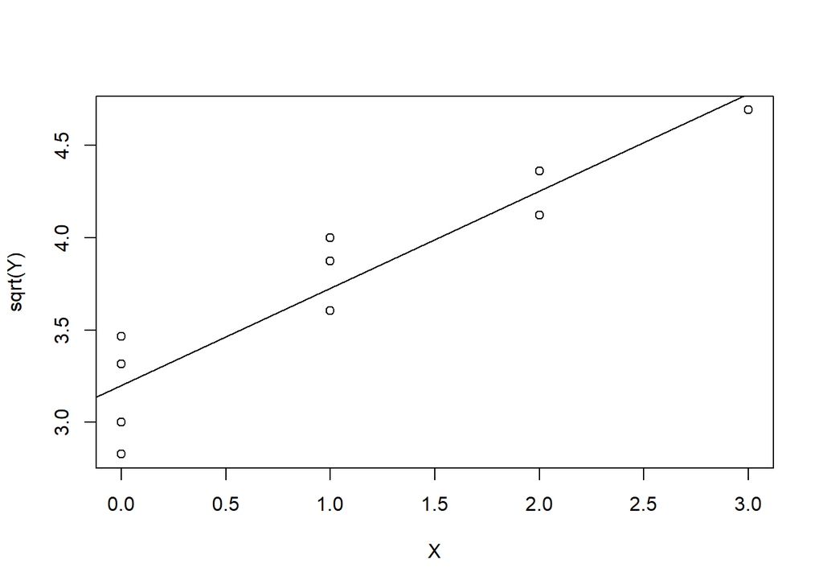

```r
plot(X, sqrt(Y))
abline(lm(sqrt(Y)~X))
```

**Residual Plot**

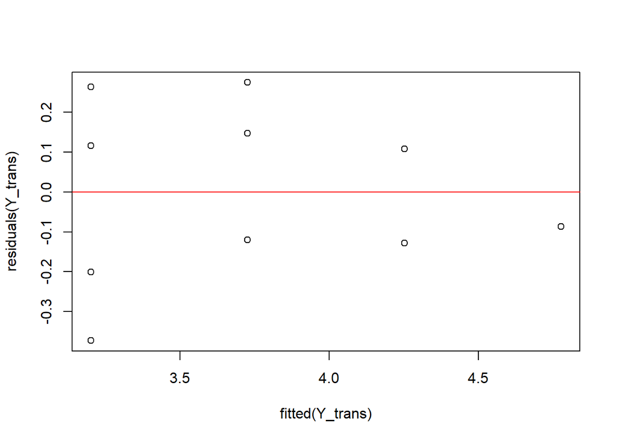

```r
plot(fitted(Y_trans), residuals(Y_trans))
abline(0,0, col = "red")
```

## Initializing Matrices

```r
A <- matrix(c(1, 4,
              2, 6,
              3, 8), ncol = 2, byrow = TRUE)


B <- matrix(c(1, 3,
              1, 4,
              2, 5), ncol = 2, byrow = TRUE)


C <- matrix(c(3, 8, 1,
              5, 4, 0), ncol = 3, byrow = TRUE)

D <- matrix(c(5, 3,
              15, 6), ncol = 2, byrow = TRUE)
D
```

```
##      [,1] [,2]
## [1,]    5    3
## [2,]   15    6
```

## Transpose of Matrices

```r
t(B)
```

```
##      [,1] [,2] [,3]
## [1,]    1    1    2
## [2,]    3    4    5
```

## Inverse of Matrices

**Remark:** To inverse a matrix, it has to square!

```r
solve(D)
```

```
##      [,1]       [,2]
## [1,] -0.4  0.2000000
## [2,]  1.0 -0.3333333
```

## Multiplication of uneven dimensions

```r
A %*% C -> mult.res
mult.res
```

```
##      [,1] [,2] [,3]
## [1,]   23   24    1
## [2,]   36   40    2
## [3,]   49   56    3
```

## Getting the dimensions of Matrices

```r
dim(mult.res)
```

```
## [1] 3 3
```

## Intercept and Slope using Matrices

```r
Y <- matrix(c(124,
              95,
              71,
              45,
              18), ncol = 1, byrow = TRUE)

X <- matrix(c(1, 49,
              1, 69,
              1, 89,
              1, 99,
              1, 109), ncol = 2, byrow = TRUE)

t(X) -> transposeX
# transposeX

dim(X)
```

```
## [1] 5 2
```

```r
transposeX%*%X -> Product2
# Product2

det(Product2)
```

```
## [1] 11600
```

```r
solve(Product2)
```

```
##             [,1]          [,2]
## [1,]  3.16939655 -0.0357758621
## [2,] -0.03577586  0.0004310345
```

```r
interceptandslope <- solve(Product2)%*%transposeX%*%Y

interceptandslope
```

```
##            [,1]
## [1,] 211.270690
## [2,]  -1.694828
```

**Remark:** Intercept = 211.27, and Slope = -1.6948

## Fitted values using Matrices

```r
X %*% interceptandslope
```

```
##           [,1]
## [1,] 128.22414
## [2,]  94.32759
## [3,]  60.43103
## [4,]  43.48276
## [5,]  26.53448
```

## Residuals using Matrices

```r
Y - X %*% interceptandslope
```

```
##            [,1]
## [1,] -4.2241379
## [2,]  0.6724138
## [3,] 10.5689655
## [4,]  1.5172414
## [5,] -8.5344828
```

## Solving (simultaneous) equation using Matrix

```r
R <- matrix(c(20,
              10), ncol = 1, byrow = TRUE)
 # R


 Q <- matrix(c(2,4,
               3,1), ncol = 2, byrow =TRUE)
 # Q

 # det(Q)

 # solve(Q)

 solve(Q)%*%R
```

```
##      [,1]
## [1,]    2
## [2,]    4
```

## Rank and Linear Independence of a Matrix

```r
library(Matrix)
 C <- matrix(c(1,  5,  8,  3,
               2,  7,  2,  6,
               3,  1,  11, 9),
             ncol = 4, byrow = TRUE)

rankMatrix(C)[1]
```

```
## [1] 3
```

```r
rankMatrix(t(C)) == rankMatrix(C)
```

```
## [1] TRUE
```

The maximum number of linearly independent column vectors is 3.

Column vector 4 is a multiple of column vector 1 if column vector 1 is multiplied by 3. Hence, the columns of C are linearly dependent. Since there is just 1 column vector out of 4 column vectors, the maximum number of independent column vectors = 4 - 1 = 3.

## Inverse of a Matrix

```r
A <- matrix(c(5, 1, 3,
              4, 0, 5,
              1, 9, 6),
            ncol = 3,
            byrow = TRUE)

solve(A)
```

```
##            [,1]       [,2]        [,3]
## [1,]  0.3308824 -0.1544118 -0.03676471
## [2,]  0.1397059 -0.1985294  0.09558824
## [3,] -0.2647059  0.3235294  0.02941176
```

## Verification of Inverse Matrix.

```r
round(solve(A) %*% A, digits = 0)
```

```
##      [,1] [,2] [,3]
## [1,]    1    0    0
## [2,]    0    1    0
## [3,]    0    0    1
```

The inverse of a matrix multiplied by the matrix should give an Identity matrix as above.